#Study Guide Week 10 Name __________________________  
#DATA 110 Date ___________________________  
#Saidi  
#Working with Continuous Variables and HighCharter  
#Fine tuning plots in tidyverse with continuous variables using dslabs  
#Highcharter  
#Data 110 Week 10 DSLabs and Highcharter  
#Rachel Saidi  
#October 24, 2019  
#Use the package DSLabs (Data Science Labs)  
#There are a number of datasets in this package to use to practice creating visualizations

```r
library("dslabs")
data(package="dslabs")
list.files(system.file("script", package = "dslabs"))
```

```
##  [1] "make-admissions.R"
##  [2] "make-brca.R"
##  [3] "make-brexit_polls.R"
##  [4] "make-death_prob.R"
##  [5] "make-divorce_margarine.R"
##  [6] "make-gapminder-rdas.R"
##  [7] "make-greenhouse_gases.R"
##  [8] "make-historic_co2.R"
##  [9] "make-mnist_27.R"
## [10] "make-movielens.R"
## [11] "make-murders-rda.R"
## [12] "make-na_example-rda.R"
## [13] "make-nyc_regents_scores.R"
## [14] "make-olive.R"
## [15] "make-outlier_example.R"
## [16] "make-polls_2008.R"
## [17] "make-polls_us_election_2016.R"
## [18] "make-reported_heights-rda.R"
## [19] "make-research_funding_rates.R"
## [20] "make-stars.R"
## [21] "make-temp_carbon.R"
## [22] "make-tissue-gene-expression.R"
## [23] "make-trump_tweets.R"
## [24] "make-weekly_us_contagious_diseases.R"
## [25] "save-gapminder-example-csv.R"
```

#Note that the package dslabs also includes some of the scripts used to wrangle the data from their original source: US murders  
#This dataset includes gun murder data for US states in 2010. I use this dataset to introduce the basics of R program.

```r
data("murders")
library(tidyverse)
library(ggthemes)
library(ggrepel)
str(murders)
```

```
## 'data.frame':    51 obs. of  5 variables:
##  $ state     : chr  "Alabama" "Alaska" "Arizona" "Arkansas" ...
##  $ abb       : chr  "AL" "AK" "AZ" "AR" ...
##  $ region    : Factor w/ 4 levels "Northeast","South",..: 2 4 4 2 4 4 1 2 2 2 ...
##  $ population: num  4779736 710231 6392017 2915918 37253956 ...
##  $ total     : num  135 19 232 93 1257 ...
```

```r
#save the murders dataset to your folder using the write_csv command
#write_csv(murders, "murders.csv", na="")
```

#Work with the Murders Dataset  
#Calculate the average murder rate for the country  
#Once we determine the per million rate to be r, this line is defined by the formula: y=rx, with y and x our axes: total murders and population in millions respectively.  
#In the log-scale this line turns into: log(y)=log(r)+log(x). So in our plot it’s a line with slope 1 and intercept log(r). To compute r, we use dplyr:  
#The pull command selects a column in a data frame and transforms it into a vector

```r
r <- murders %>%
  summarize(rate = sum(total) /  sum(population) * 10^6) %>%
  pull(rate)
```

#Create a static graph for which each point is labeled

#Use the data science theme. Plot using the x-axis as population for each state per million, the y-axis as the total murders for each state.  
#Color by region, add a linear regression line based on your calculation for r above, where we only need the intercept: geom_abline(intercept = log10(r))  
#Scale the x- and y-axes by a factor of log 10, add axes labels and a title.  
#You can use the command nudge_x argument, if you want to move the text slightly to the right or to the left:

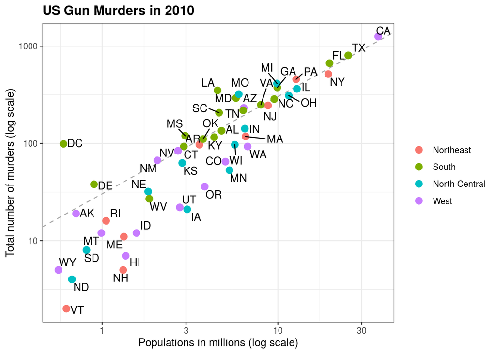

```r
ds_theme_set()
murders %>%
  ggplot(aes(x = population/10^6, y = total, label = abb)) +
  geom_abline(intercept = log10(r), lty=2, col="darkgrey") +
  geom_point(aes(color=region), size = 3) +
  geom_text_repel(nudge_x = 0.005) +
  scale_x_log10("Populations in millions (log scale)") +
  scale_y_log10("Total number of murders (log scale)") +
  ggtitle("US Gun Murders in 2010") +
  scale_color_discrete(name="Region") +
#Remove legend title
  theme(legend.title=element_blank())
```

#Gapminder Dataset  
#This dataset includes health and income outcomes for 184 countries from 1960 to 2016. It also includes two character vectors, OECD and OPEC, with the names of OECD and OPEC countries from 2016.  
#Name the regions using the code %in% : The West, East Asia, Latin America, Sub-Saharan Africa, and Others

```r
data("gapminder")

west <- c("Western Europe","Northern Europe","Southern Europe",
          "Northern America","Australia and New Zealand")

gapminder <- gapminder %>%
  mutate(group = case_when(
    region %in% west ~ "The West",
    region %in% c("Eastern Asia", "South-Eastern Asia") ~ "East Asia",
    region %in% c("Caribbean", "Central America", "South America") ~ "Latin America",
    continent == "Africa" & region != "Northern Africa" ~ "Sub-Saharan Africa",
    TRUE ~ "Others"))

gapminder <- gapminder %>%
  mutate(group = factor(group, levels = rev(c("Others", "Latin America", "East Asia","Sub-Saharan Africa", "The West"))))
```

#1. Remove all na values from “group”, “fertility”, and “life_expectancy” using !is.na (works the same as na.rm = TRUE)  
#2. mutate the population to be a value per million  
#3. change the theme of the plot  
#4. Use the command: geom_text(aes(x=7, y=82, label=year), cex=12, color=“grey”) to label the two plots at the top right inside the plots (by their years).  
#5. Shift the legend to go across the top.

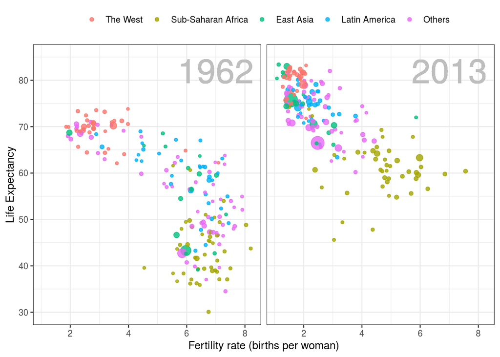

```r
gapminder %>%
  filter(year%in%c(1962, 2013) & !is.na(group) &
         !is.na(fertility) & !is.na(life_expectancy)) %>%
  mutate(population_in_millions = population/10^6) %>%
  ggplot( aes(fertility, y=life_expectancy, col = group, size = population_in_millions)) +
  geom_point(alpha = 0.8) +
  guides(size=FALSE) +
  theme(plot.title = element_blank(), legend.title = element_blank()) +
  coord_cartesian(ylim = c(30, 85)) +
  xlab("Fertility rate (births per woman)") +
  ylab("Life Expectancy") +
  geom_text(aes(x=7, y=82, label=year), cex=12, color="grey") +
  facet_grid(. ~ year) +
  theme(strip.background = element_blank(),
        strip.text.x = element_blank(),
        strip.text.y = element_blank(),
   legend.position = "top")
```

#Contagious disease data for US states  
#The next dataset contains yearly counts for Hepatitis A, measles, mumps, pertussis, polio, rubella, and smallpox for US states. Original data courtesy of Tycho Project. Use it to show ways one can plot more than 2 dimensions.  
#Focus on just measles 1. filter out Alaska and Hawaii  
#2. mutate the rate of measles by taking the count/(population10,00052)/weeks_reporting  
#3. draw a vertical line for 1963, which is when the measles vaccination was developed

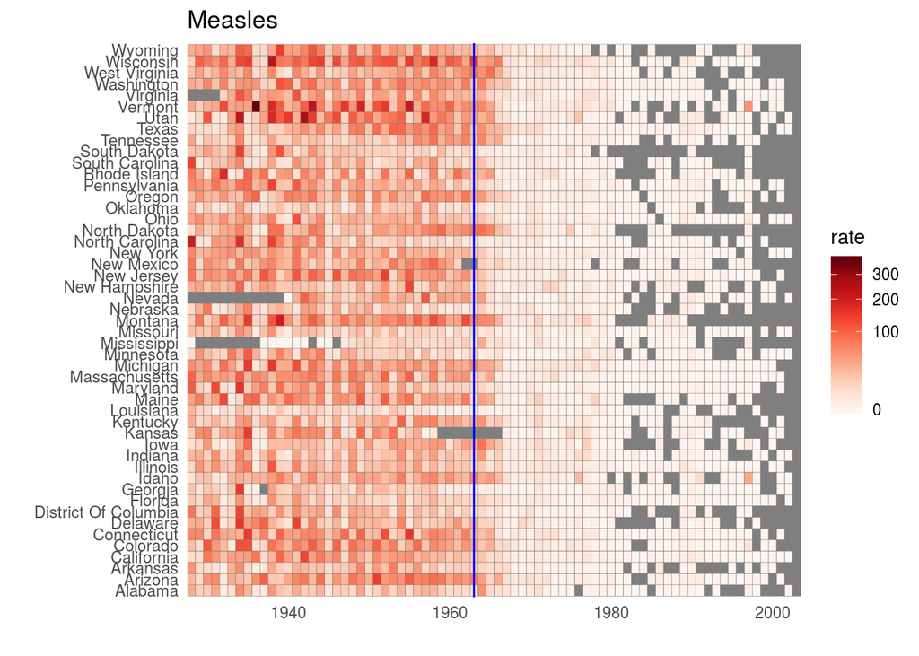

```r
library(RColorBrewer)
data("us_contagious_diseases")
the_disease <- "Measles"

us_contagious_diseases %>%
  filter(!state%in%c("Hawaii","Alaska") & disease ==  the_disease) %>%
  mutate(rate = count / population * 10000 * 52 / weeks_reporting) %>%
  mutate(state = reorder(state, rate)) %>%
  ggplot(aes(year, state,  fill = rate)) +
  geom_tile(color = "grey50") +
  scale_x_continuous(expand=c(0,0)) +
  scale_fill_gradientn(colors = brewer.pal(9, "Reds"), trans = "sqrt") +
  geom_vline(xintercept=1963, col = "blue") +
  theme_minimal() +  theme(panel.grid = element_blank()) +
  ggtitle(the_disease) +
  ylab("") +
  xlab("")
```

#Fivethirtyeight 2016 Poll Data  
#This data includes poll results from the US 2016 presidential elections aggregated from HuffPost Pollster, RealClearPolitics, polling firms and news reports. The dataset also includes election results (popular vote) and electoral college votes in results_us_election_2016. Use this dataset to explore inference.  
#1. Focus on polls for Clinton and Trump after July 2016  
#2. Plot a scatterplot of the enddate to the percentage in the polls  
#3. Include a loess smoother regression

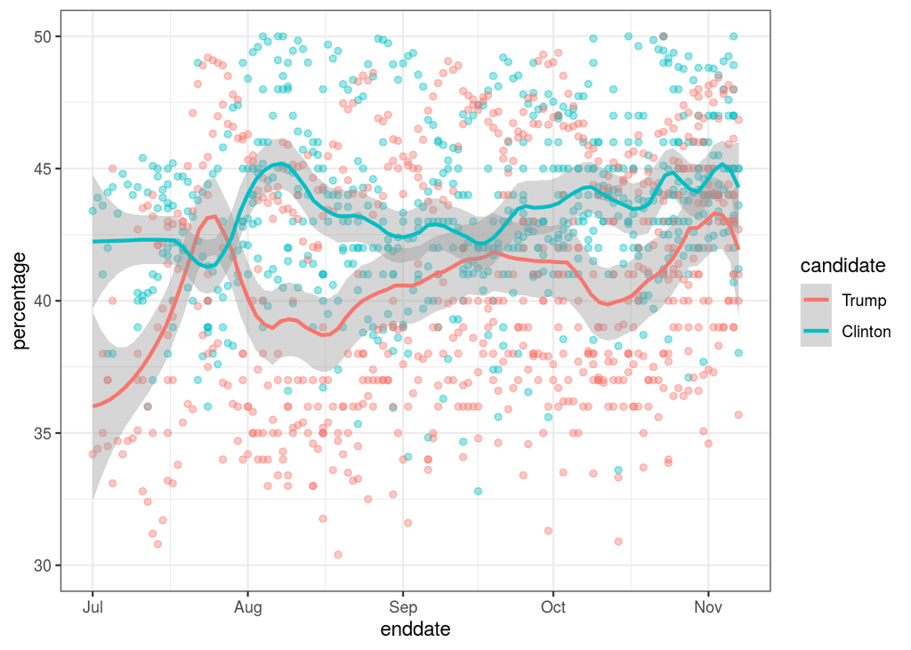

```r
data(polls_us_election_2016)
polls_us_election_2016 %>%
  filter(state == "U.S." & enddate>="2016-07-01") %>%
  select(enddate, pollster, rawpoll_clinton, rawpoll_trump) %>%
  rename(Clinton = rawpoll_clinton, Trump = rawpoll_trump) %>%
  gather(candidate, percentage, -enddate, -pollster) %>%
  mutate(candidate = factor(candidate, levels = c("Trump","Clinton")))%>%
  group_by(pollster) %>%
  filter(n()>=10) %>%
  ungroup() %>%
  ggplot(aes(enddate, percentage, color = candidate)) +
  geom_point(show.legend = FALSE, alpha=0.4)  +
  geom_smooth(method = "loess", span = 0.15) +
  scale_y_continuous(limits = c(30,50))
```

#Working with HTML Widgets and Highcharter  
#Set your working directory to access your files

```r
library(readr)
library(ggplot2)
library(scales)
library(dplyr)
```

#Make a range of simple charts using the highcharter package  
#Highcharter is a package within the htmlwidgets framework that connects R to the Highcharts and Highstock JavaScript visualization libraries. For more information, see https://github.com/jbkunst/highcharter/  
#Also check out this site: https://cran.r-project.org/web/packages/highcharter/vignettes/charting-data-frames.html  
#Install and load required packages  
#Now install and load highcharter, plus RColorBrewer, which will make it possible to use ColorBrewer color palettes.  
#Also load dplyr and readr for loading and processing data.

```r
library(highcharter)
library(RColorBrewer)
#Load and process nations data
#Load the nations data, and add a column showing GDP in trillions of dollars.
nations <- read_csv("nations.csv") %>%
  mutate(gdp_tn = gdp_percap*population/1000000000000)
```

#Make a version of the “China’s rise” chart you’re your prior assignment  
#First, prepare the data using dplyr:  
#prepare data

```r
big4 <- nations %>%
  filter(iso3c == "CHN" | iso3c == "DEU" | iso3c == "JPN" | iso3c == "USA") %>%
  arrange(year)

#The arrange step is important, because highcharter needs the data in order when drawing a time series - otherwise any line drawn through the data will follow the path of the data order, not the correct time order.
#Now draw a basic chart with default settings:
#basic symbol-and-line chart, default settings

highchart() %>%
  hc_add_series(data = big4,
                   type = "line", hcaes(x = year,
                   y = gdp_tn,
                   group = country))
```

[interactive chart not shown]

#In the code above, the function highchart() creates a chart.  
#Clicking on the legend items allows you to remove or add series from the chart.  
#Highcharts works by adding data “series” to a chart, and from R you can add the variables from a data frame all in one go using the hc_add_series function.  
#Inside this function we define the data frame to be used, with data, the type of chart, the variables to be mapped to the x and y axes, and the variable to group the data: here this draws a separate line for each country in the data.  
#Go to the github site provided above for the chart types available in Highcharts.  
#Now let’s begin customizing the chart.  
#Use a ColorBrewer palette  
#Using RColorBrewer, we can set a palette, and then use it in highcharter.  
#define color palette

```r
cols <- brewer.pal(4, "Set1")

highchart() %>%
  hc_add_series(data = big4,
                   type = "line", hcaes(x = year,
                   y = gdp_tn,
                   group = country)) %>%
  hc_colors(cols)
```

[interactive chart not shown]

#The first line of code sets a palette with four colors, using the “Set1” palette from ColorBrewer. This is then fed to the function hc_colors() to use those colors on the chart.

```r
#Add axis labels
highchart() %>%
  hc_add_series(data = big4,
                   type = "line",
                   hcaes(x = year,
                   y = gdp_tn,
                   group = country)) %>%
  hc_colors(cols) %>%
  hc_xAxis(title = list(text="Year")) %>%
  hc_yAxis(title = list(text="GDP ($ trillion)"))
```

[interactive chart not shown]

```r
#Change the legend position
#For this, we use the hc_legend function.

highchart() %>%
  hc_add_series(data = big4,
                   type = "line",
                   hcaes(x = year,
                   y = gdp_tn,
                   group = country)) %>%
  hc_colors(cols) %>%
  hc_xAxis(title = list(text="Year")) %>%
  hc_yAxis(title = list(text="GDP ($ trillion)")) %>%
  hc_plotOptions(series = list(marker = list(symbol = "circle"))) %>%
  hc_legend(align = "right",
            verticalAlign = "top")
```

[interactive chart not shown]

#Customize the tooltips  
#By default we have a tooltip for each series, or line, and the numbers run to many decimal places.  
#We can change to one tooltip for each year with “shared = TRUE”, and round all the numbers to two decimal places with pointFormat = "{point.country}: {point.gdp_tn:.2f}

```r
#customize the tooltips

big4_chart <- highchart() %>%
  hc_add_series(data = big4,
                   type = "line",
                   hcaes(x = year,
                   y = gdp_tn,
                   group = country)) %>%
  hc_colors(cols) %>%
  hc_xAxis(title = list(text="Year")) %>%
  hc_yAxis(title = list(text="GDP ($ trillion)")) %>%
  hc_plotOptions(series = list(marker = list(symbol = "circle"))) %>%
  hc_legend(align = "right",
            verticalAlign = "top") %>%
  hc_tooltip(shared = TRUE,
             borderColor = "black",
             pointFormat = "{point.country}: {point.gdp_tn:.2f}<br>")
big4_chart
```

[interactive chart not shown]

#Prepare the data  
#First, prepare the data using dplyr.  
#prepare data

```r
regions <- nations %>%
  group_by(year,region) %>%
  summarize(gdp_tn = sum(gdp_tn, na.rm = TRUE)) %>%
  arrange(year,region)
```

#Make an area chart using default options

#basic area chart, default options

```r
highchart () %>%
  hc_add_series(data = regions,
                   type = "area",
                   hcaes(x = year,
                   y = gdp_tn,
                   group = region))
```

[interactive chart not shown]

#The following code customizes the chart in other ways. It uses the same ColorBrewer palette, with seven colors, that we used in unit 3.  
#set color palette

```r
cols <- brewer.pal(7, "Set2")

#stacked area chart

highchart () %>%
  hc_add_series(data = regions,
                   type = "area",
                   hcaes(x = year,
                   y = gdp_tn,
                   group = region)) %>%
  hc_colors(cols) %>%
  hc_chart(style = list(fontFamily = "Georgia",
                        fontWeight = "bold")) %>%
  hc_plotOptions(series = list(stacking = "normal",
                               marker = list(enabled = FALSE,
                               states = list(hover = list(enabled = FALSE))),
                               lineWidth = 0.5,
                               lineColor = "white")) %>%
  hc_xAxis(title = list(text="Year")) %>%
  hc_yAxis(title = list(text="GDP ($ trillion)")) %>%
  hc_legend(align = "right", verticalAlign = "top",
            layout = "vertical") %>%
  hc_tooltip(enabled = FALSE)
```

[interactive chart not shown]

#We have already encountered the main functions used here. The key changes are in the hc_plotOptions() function:  
#stacking = “normal” creates the stacked chart. See what happens if you use stacking = “percent”.  
#lineWidth and lineColor set the width and color for the lines under marker = list() the code states = list(hover = list(enabled = FALSE)) turns off the hovering effect for each marker on the chart, so that the markers no longer reappear when hovered or tapped.  
#In the hc_legend() function, layout = “vertical” changes the layout so that the legend items appear in a vertical column.  
#Food Stamps Data - Combine Two Types

```r
cols <- c("red","black")
food_stamps<- read_csv("food_stamps.csv")
```

```r
highchart() %>%
  hc_yAxis_multiples(
    list(title = list(text = "Participants (millions)")),
    list(title = list(text = "Costs ($ billions)"),
         opposite = TRUE)
  ) %>%
  hc_add_series(data = food_stamps$participants,
                name = "Participants (millions)",
                type = "column",
                yAxis = 0) %>%
  hc_add_series(data = food_stamps$costs,
                name = "Costs ($ billions)",
                type = "line",
                yAxis = 1) %>%
  hc_xAxis(categories = food_stamps$year,
           tickInterval = 5) %>%
  hc_colors(cols) %>%
  hc_chart(style = list(fontFamily = "Georgia",
                        fontWeight = "bold"))
```

[interactive chart not shown]

#Assignment for Week 10 Using DSLabs Datasets

#(Worth up to 20 points) Take any of the datasets included in “dslabs” and create a new multivariable graph. You may use any of the datasests including those for the four examples above, as long as you change something meaningful about the graph. You must include the following in your graph:  
#Labels for x- and y-axes and a title  
#A theme for the graph (you must change the generic ggplot style)  
#Colors for a third variable, with a legend.  
#You can create a scatterplot or heatmap for continuous variables. You may not create a bar graph for categorical variables for this assignment. Feel free to incorporate items from Week 9 as well. In your RMD file / Rpubs document, be sure you describe in a paragraph what dataset you have used and document how you have created your graph. If you choose to use one of the datasets from the 4 above examples, be sure I can clearly understand what you have done differently.  
#This assignment is due Monday, November 11th, at 11:59 pm. As usual, be ready to present this to the class the following week.